# Måling og deskriptiv statistik

Metode 1 F26 #4

Søren Damsbo-Svendsen

4. marts 2026

## Temaer

- Måling er en del af at **operationalisere** et begreb
- Operationalisering er en af de vigtigste discipliner i statskundskaben
- Måleniveauer: nominel, ordinal og intervalskaleret (plus binær)
- Univariat, deskriptiv statistik: central tendens og spredning
- I gang med R!

## Hovedpointer

1. En variabels **måleniveau er et konceptuelt valg** med vigtige implikationer for analyse/statistik
2. Umuligt at komme uden om **deskriptiv statistik** i samfundsvidenskaben
   - forskningsspørgsmål om politiske fænomener: hvor meget, hvor intensivt, i hvilken grad (evt. udvikling, sammenligning, kontekst)
   - godt udgangspunkt: *gennemsnit* (central tendens) og *standardafvigelse* (spredning)
   - basis for avancerede metoder

## Plan for forelæsningen

1. I gang med R: fil-/projekthåndtering og basal datamanipulation
2. Måling og måleniveauer (operationalisering)
3. Pause
4. Deskriptiv statistik

## Fil-/projekthåndtering i R(Studio)

- lav altid en mappe til projektet og gem *alle* projektets filer dér
- lav undermapper (fx ‘data’, ‘figurer’)
- når det er sat rigtigt op, bruger R relative stier → leder efter filer i projektmappen
- når du åbner et R-script, der ligger i projektmappen, starter R op dér (= *working directory*)
- du kan tjekke dit den aktive projektmappe (*working directory*) med `getwd()`
- eller indstille den med `setwd("sti_til_projektmappen")`
- mellem `""` kan du med [tab] (auto-complete) søge dig frem til filer

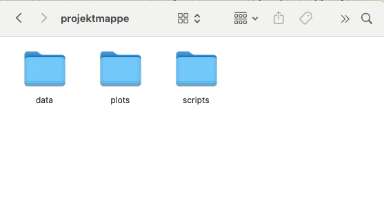

## Fil-/projekthåndtering i R(Studio)

Når du skal indlæse en datafil, skal du kende:

1. dens **filnavn**: fx `Dataset.dta`
2. dens absolutte eller relative **sti** (inden for projektmappen):
   - ‘~/uni/projektmappe/data/Dataset.dta’
   - ‘data/Dataset.dta’
3. dens **filtype** → afgør hvilken **R-funktion** du skal bruge:
   - `dat <- haven::read_dta("data/Dataset.dta)` # stata (ofte smart pga. labels)
   - `dat <- readxl::read_excel("data/Dataset.xlsx"` # excel
   - `dat <- readr::read_rds("data/Dataset.rds")` # R
   - `dat <- readr::read_csv("data/Dataset.csv")` # csv (komma)
   - `dat <- readr::read_csv2("data/Dataset.csv")` # csv (semikolon)
   - samme for SAS, SPSS, txt, etc.
   - (.RData-filer dobbeltklikker man bare på)

## Basal datamanipulation med {dplyr} (tidyverse)

- `select():` vælger eller fravælger (sletter) kolonner
  - også kolonnernes rækkefølge
  - mange smarte måder at bruge select
  - `data |> select(var1, var2, var11, var5, -var20)`
- `arrange():` sorterer rækkerne betinget af en eller flere variable
  - `data |> arrange(var2, desc(var11))`
- `filter():` nøglefunktionen til at fjerne – eller beholde – enheder/rækker baseret på deres værdier på en eller flere variable
  - *betingelser* der (ikke) skal opfyldes
  - fx til at fjerne NA, eller en vis aldersgruppe eller “Ved ikke”
  - eller til at beholde valide/udvalgte værdier
  - `!` betyder ‘ikke’, komma adskiller vores filtre
  - `data |> filter(!is.na(var1), alder < 50, spg5 %in% c(1,2,3,4,5))`

## Basal datamanipulation med {dplyr} (tidyverse)

- `mutate()`: nøglefunktionen til at konstruere/ændre variable på enhver måde  
  (i samme *dataframe*)
  - power duo når `mutate()` kombineres den med `ifelse()`
- `summarise()`: nøglefunktionen til at opsummere data/variable, fx lave deskriptiv statistik (skaber en ny, mindre *dataframe*)
  - bruges fx sammen med statistik-funktioner: `mean()`, `median()`, `first()`, `min()`, `max()`, etc.
- `group_by():` brug filter, mutate, summarise etc. *inden for* grupper defineret ved en variabel, fx til at beregne gennemsnit for hvert parti:
  - `data |> group_by(parti) |> summarise(gns = mean(var1)) |> ungroup()`
  - altid godt at køre `ungroup()` efter `group_by(var)` for at droppe gruppestrukturen og undgå fejl

## Basal datamanipulation med {dplyr} (tidyverse)

- `select()`, `arrange()`, `filter()`, `mutate()`, `summarise()`, `group_by()` og `ungroup()` er et godt udgangspunkt sammen med `read_*()`
- Essentielt at kunne anvende disse – og andre relaterede – funktioner
- **Læs Larsen (2024) og lav øvelserne**
- Se evt. Heiss (2024)<sup>1</sup> for animationer af logikken i `mutate()`, `summarise()` og `group_by()` → `summarise()` → `ungroup()`
- Gå til kilden → fx Hadley Wickham:  
  https://r4ds.hadley.nz/data-transform.html
- Se YouTube, find online tutorials
[^1]: https://www.andrewheiss.com/blog/2024/04/04/group_by-summarize-ungroup-animations/

## Hjælp fra AI etc.

- Spørg gerne ChatGPT/Claude osv.
- Men man er nødt til at gøre arbejdet selv – især i begyndelsen – ellers lærer man det ikke ordentligt
- Ellers kan man (heller) ikke blive ekspert i at bruge AI …

## Hjælp fra AI etc.

> “The only way to gain domain knowledge, **data analysis expertise**, and **coding ability** is to **struggle**. To **get errors**. To google those errors. To look over the documentation. To copy/paste your own code and adapt it for different purposes. To **explore messy datasets**. To struggle to clean those datasets. To *spend an hour looking for a missing comma.*

> This isn’t a form of programming hazing, like “I had to walk to school uphill both ways in the snow and now you must too.” **It’s the actual process of learning** and growing and developing and improving. You’ve gotta struggle.” (Heiss 2025<sup>1</sup>)

Now is your chance! 🙃

[^2]: https://datavizf25.classes.andrewheiss.com/news/2025-12-10_faqs_week-15.html

# Måling og operationalisering

## Måling og operationalisering

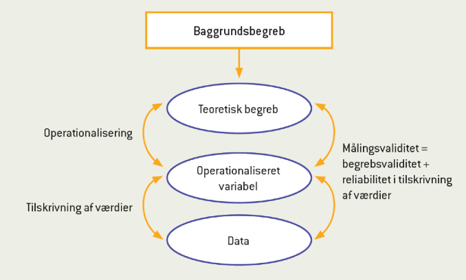

MIS figur 4.1

## Måling og operationalisering

- **Måling:** Tilskrivning af værdier til et teoretisk begreb for en række enheder
- Værdier = tal (som udgangspunkt…)
- Iterativ proces, der kan begynde flere steder
- Kræver refleksion
- En af statskundskabens styrker
- **Måleniveauer**: måder at tilskrive tal til enhederne (= måle)
- Afhænger bl.a. af
  - fænomenet: har det fx en kvantitativ karakter (alder, demokrati, opbakning til politik, køn)?
  - udfaldsrummet: fx 0 – ∞ eller 1, 2, 3 eller ‘ja’, ‘nej’?

## Enhed, variabel og værdi

```r
set.seed(25)
df <- tibble(var1 = sample(letters[1:5], 5, replace = TRUE),
             var2 = sample(1:5, 5, replace = TRUE),
             var3 = runif(5, min = 1, max = 100)) |>
  mutate(enhed_nr = row_number(), .before = everything())
kable(df, digits = 2)
```

| enhed_nr | var1 | var2 | var3 |
| --- | --- | --- | --- |
| 1 | e | 2 | 54.43 |
| 2 | d | 3 | 73.09 |
| 3 | a | 4 | 48.21 |
| 4 | a | 1 | 73.21 |
| 5 | a | 3 | 5.03 |

*n* = ???

## Operationalisering og måling — eksempel

- **Teoretisk begreb**: (gruppebaseret) *politisk respekt*
- **Operationaliseret variabel**: “*I hvilket omfang synes du, at grupperne nedenfor bliver mødt med den respekt fra samfundet, som de fortjener?*” Fra 0 (slet ikke) til 10 (i meget høj grad)
- **Data**: Heltal mellem 0 og 10
  - afspejler en rangordet (ordinal) skala
  - som udgangspunkt lige langt fra 1-2 og 5-6
  - kunne hypotetisk forestille sig 8,5 (ikke kun heltal)
  - helt sikkert *ordinalt* og kan med god ret betragtes som *intervalskaleret*

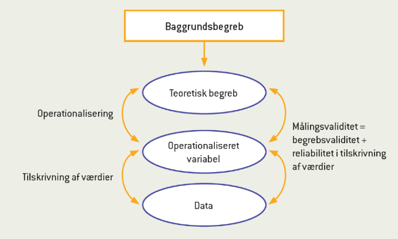

MIS figur 4.1

## Tre måleniveauer + et ekstra

1. **Intervalskaleret**
2. **Ordinal**
3. **Nominel**
4. **Binær** (ekstra)

## Tre måleniveauer + et ekstra

1. **Intervalskaleret** ≈ kontinuert variabel
   - (let at gøre) numerisk
   - tydeligt rangordnet
   - konstant afstand mellem tal (konceptuelt)
   - fx alder (0, 1, 2, 3, 4)
2. **Ordinal** ≈ diskret variabel
   - (let at gøre) numerisk
   - tydeligt rangordnet
   - varierende afstand mellem tal (konceptuelt)
   - fx politisk interesse (3 meget, 2 lidt, 1 ingen)

## Tre måleniveauer + et ekstra

3. **Nominel** ≈ kategorisk variabel
   - ikke numerisk (kan tildeles arbitrære heltal – dvs. ‘kodes’)
   - *ikke* rangordnet, men separate *kategorier*
   - ‘afstand’ meningsløst
   - fx partivalg (1 socialdemokratiet, 2 radikale, 3 konservative)
4. **Binær** ≈ dikotom variabel ≈ dummyvariabel ≈ indikatorvariabel
   - ikke numerisk? Jo, pga. konvention: 1 = ja, 0 = nej
   - rangordnet?
   - ‘afstand’ meningsløst
   - fx valgdeltagelse (1 stemte, 0 stemte ikke)
   - særlig variant af nominel (også slægtskab med de andre)

## Måleniveauer og statistisk metode

- Mange statistiske metoder antager/kræver **intervalskalerede** (eller binære) variable
- Variable med **nominelt** måleniveau kan omformes til et sæt af **binære** variable før analysen
- Data kan sagtens indsamles/gemmes som fx **rå tekst**, men skal *encodes* med (hel)tal før analysen
- Noget af dette gør R automatisk
- Rige muligheder for at **omforme variable til et andet måleniveau** eller justere antagelser
- Men vi kan ikke *tilføre* mere information, kun bortkaste/tilpasse

> Vigtig pointe: Måleniveauet er et valg, du selv skal træffe!

## Måleniveauet er et valg, du selv skal træffe!

- der er bedre, dårligere og helt umulige valg
- men ultimativt flere muligheder
- kræver reflektion og argumentation
- baseret på forskningsspørgsmål og analyse/metoder
- god tommelfingerregel: bevar variation (intervalskaleret)
  - men der kan være gode grunde til at foretrække binære/nominelle variable

## Måleniveauer i valgundersøgelsen

Åbn **vu22_skema_uddrag.pdf**

- fx spg.
  - 1-2, 5 (køn, alder, antal børn)
  - 34 (partirepræsentation)
  - 45 (skat)
  - 47 (holdninger)

**Intervalskaleret, ordinal, nominel eller binær?**

## Manglende værdier

- ofte mangler der værdier
- fx “ved ikke”, ekstreme målefejl eller deciderede mgl. observationer
- passer ikke ind på en enkelt numerisk skala / ødelægger måleniveauet

```r
kable(df, digits = 2)
```

| enhed_nr | var1 | var2 | var3 |
| --- | --- | --- | --- |
| 1 | e | 2 | 54.43 |
| 2 | d | 3 | 73.09 |
| 3 | a | 4 | 48.21 |
| 4 | a | 1 | 73.21 |
| 5 | a | 3 | 5.03 |

```r
df_miss <- df |>
  mutate(var1 = na_if(var1, "e"),
         var2 = na_if(var2, 4),
         var3 = ifelse(var3 > 50, NA, var3))

df_miss |>
  mutate(var1 = ifelse(is.na(var1), cell_spec(var1, background = "pink"), var1),
         var2 = ifelse(is.na(var2), cell_spec(var2, background = "pink"), var2),
         var3 = ifelse(is.na(var3), cell_spec(var3, background = "pink"), round(var3, 2))) |>
  kable(digits = 2)
```

| enhed_nr | var1 | var2 | var3 |
| --- | --- | --- | --- |
| 1 | NA | 2 | NA |
| 2 | d | 3 | NA |
| 3 | a | NA | 48.21 |
| 4 | a | 1 | NA |
| 5 | a | 3 | 5.03 |

## Kategoriske variable = ikke så farligt

- Betragter bare manglende værdier (NAs) som egen kategori
- Kode dem sådan (fx “ved ikke” eller “missing”) eller få R til at vise NAs
- Største fare: at overse at de er der

```r
# frekvenstabel: tving R til at vise NAs
table(df_miss$var1, useNA = "always")
```

```
   a    d <NA>
   3    1    1
```

```r
# eller giv NAs egen kategori (tidy tilgang)
df_miss |>
  mutate(var1 = replace_na(var1, "missing")) |>
  count(var1) |> # count(x) er kort for group_by(x) |> summarise(n = n()) |> ungroup()
  mutate(procent = n / sum(n) * 100)
```

```
# A tibble: 3 × 3
  var1        n procent
  <chr>   <int>   <dbl>
1 a           3      60
2 d           1      20
3 missing     1      20
```

## Numeriske variable = farligt

- Manglende værdier fører nemt til helt forkerte beregninger
- Typisk pga. ekstreme værdier som kode for missing (fx 999)
- Eller kan medføre fejl i R

```r
df_miss |>
  mutate(var1 = ifelse(is.na(var1), cell_spec(var1, background = "pink"), var1),
         var2 = ifelse(is.na(var2), cell_spec(var2, background = "pink"), var2),
         var3 = ifelse(is.na(var3), cell_spec(var3, background = "pink"), round(var3, 2))) |>
  kable(digits = 2)
```

| enhed_nr | var1 | var2 | var3 |
| --- | --- | --- | --- |
| 1 | NA | 2 | NA |
| 2 | d | 3 | NA |
| 3 | a | NA | 48.21 |
| 4 | a | 1 | NA |
| 5 | a | 3 | 5.03 |

```r
df_miss |>
  mutate(var1 = ifelse(is.na(var1), cell_spec("missing", background = "pink"), var1),
         var2 = ifelse(is.na(var2), cell_spec(999, background = "pink"), var2),
         var3 = ifelse(is.na(var3), cell_spec(999, background = "pink"), round(var3, 2))) |>
  kable(digits = 2)
```

| enhed_nr | var1 | var2 | var3 |
| --- | --- | --- | --- |
| 1 | missing | 2 | 999 |
| 2 | d | 3 | 999 |
| 3 | a | 999 | 48.21 |
| 4 | a | 1 | 999 |
| 5 | a | 3 | 5.03 |

## Numeriske variable: Håndtering i R

- Ved intervalskaleret eller ordinalt måleniveau, *skal* de håndteres før analysen
  - gælder også “Ved ikke” etc.
- Slettes/udelades typisk – eller omkodes (imputeres)

```r
df_miss |>
  mutate(var1 = ifelse(is.na(var1), cell_spec(var1, background = "pink"), var1),
         var2 = ifelse(is.na(var2), cell_spec(var2, background = "pink"), var2),
         var3 = ifelse(is.na(var3), cell_spec(var3, background = "pink"), round(var3, 2))) |>
  kable(digits = 2)
```

| enhed_nr | var1 | var2 | var3 |
| --- | --- | --- | --- |
| 1 | NA | 2 | NA |
| 2 | d | 3 | NA |
| 3 | a | NA | 48.21 |
| 4 | a | 1 | NA |
| 5 | a | 3 | 5.03 |

```r
df_miss |>
  mutate(var1 = ifelse(is.na(var1), cell_spec("missing", background = "pink"), var1),
         var2 = ifelse(is.na(var2), cell_spec(999, background = "pink"), var2),
         var3 = ifelse(is.na(var3), cell_spec(999, background = "pink"), round(var3, 2))) |>
  kable(digits = 2)
```

| enhed_nr | var1 | var2 | var3 |
| --- | --- | --- | --- |
| 1 | missing | 2 | 999 |
| 2 | d | 3 | 999 |
| 3 | a | 999 | 48.21 |
| 4 | a | 1 | 999 |
| 5 | a | 3 | 5.03 |

## Numeriske variable: Håndtering i R

##### Gennemsnit I: med NA-værdier → NA

```r
# med NA-værdier
mean(df_miss$var3)
```

```
[1] NA
```

## Numeriske variable: Håndtering i R

##### Gennemsnit II: med 999-værdier → helt forkert resultat

```r
# med 999-værdier
df_miss |>
  mutate(var3 = replace_na(var3, 999)) |>
  # pull() hiver en variabel helt ud af en data.frame
  pull(var3) |>
  mean()
```

```
[1] 610.0485
```

## Numeriske variable: Håndtering i R

##### Gennemsnit III: ignorér NAs → korrekt resultat

```r
# ignorér NA-værdier
mean(df_miss$var3, na.rm = TRUE)
```

```
[1] 26.62135
```

## Numeriske variable: Håndtering i R

##### Gennemsnit IV: fjern først NA-værdier → korrekt resultat

```r
# fjern NA-værdier (tidy)
df_miss |>
  filter(!is.na(var3)) |>
  summarise(gns = mean(var3),
            n = n())
```

```
# A tibble: 1 × 2
    gns     n
  <dbl> <int>
1  26.6     2
```

## Numeriske variable: Håndtering i R

##### Gennemsnit V: omkod først NA-værdier → korrekt

```r
# omkod NA-værdier til variablens gennemsnit uden NAs (tidy)
df_miss |>
  mutate(var3 = ifelse(is.na(var3), yes = mean(var3, na.rm = TRUE), no = var3)) |>
  summarise(gns = mean(var3),
            n = n())
```

```
# A tibble: 1 × 2
    gns     n
  <dbl> <int>
1  26.6     5
```

- (Hvordan/hvornår manglende værdier bør *imputeres* er et stort emne…)
- Når manglende værdier er håndteret – så vi får en ensartet numerisk *skala*  
  – kan vi begynde at lave **deskriptiv statistik →**

# Pause

## Spørgeskema

**Tekniske udfordringer:**

Beklager!!

**Link:**

https://019b30f0-735b-1f9a-5a5f-58b81a6121a0.share.connect.posit.cloud/?completion_code=m1f26

**Kort link:**

https://kortlink.dk/2u5uh

**Opfordring:**

Forsøg en enkelt gang mere inden weekenden

## Deskriptiv statistik

**Formål**

> At beskrive en (oftest numerisk) variabel eller det bagvedliggende fænomen med et enkelt eller få tal (statistikker)
- … så det giver mening for ‘læseren’ (kommunikation)
- fælles sprog, der er systematisk og nøjagtigt
- fundament for enormt meget videnskabelig metode

**Begreber**

- *Deskriptiv* vs. inferentiel statistik
- (Empirisk) fordeling
- Central tendens
- Spredning
- (Skævhed, spidshed)

## En variabels fordeling

**Rå data**

```r
kable(df) |>
  kableExtra::column_spec(3, background = "pink")
```

| enhed_nr | var1 | var2 | var3 |
| --- | --- | --- | --- |
| 1 | e | 2 | 54.42901 |
| 2 | d | 3 | 73.09180 |
| 3 | a | 4 | 48.21485 |
| 4 | a | 1 | 73.21021 |
| 5 | a | 3 | 5.02785 |

**Frekvenstabel**

```r
df |>
  count(var2) |>
  kable() |>
  kableExtra::column_spec(1, background = "pink")
```

| var2 | n |
| --- | --- |
| 1 | 1 |
| 2 | 1 |
| 3 | 2 |
| 4 | 1 |

## En variabels fordeling

**Frekvens** (søjlediagram)

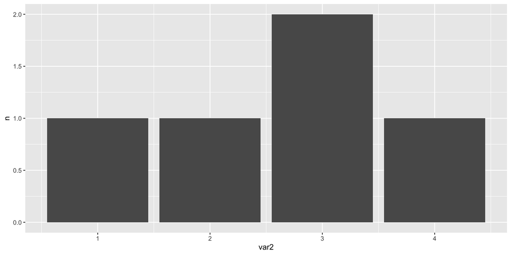

```r
df |>
  count(var2) |>
  ggplot() +
  aes(x = var2, y = n) +
  geom_col()
```

## En variabels centrale tendens

> En variabels centrale tendens er den mest typiske eller repræsentative værdi
- bare dette ene tal – fx et simpelt gennemsnit – kan fortælle os en masse
- hvad er tendensen?
- det ene tal, som fortæller os mest om variablens fordeling

## En variabels centrale tendens

1. **gennemsnit** (mean): *var3*
2. **median:** *var2*
3. **typetal** (mode): *var1*

```r
kable(df, digits = 2)
```

| enhed_nr | var1 | var2 | var3 |
| --- | --- | --- | --- |
| 1 | e | 2 | 54.43 |
| 2 | d | 3 | 73.09 |
| 3 | a | 4 | 48.21 |
| 4 | a | 1 | 73.21 |
| 5 | a | 3 | 5.03 |

```r
df |>
  summarise(enhed_nr = "den centrale tendens",
            var1 = collapse::fmode(var1),
            var2 = median(var2),
            var3 = mean(var3)) |>
  kable(digits = 2)
```

| enhed_nr | var1 | var2 | var3 |
| --- | --- | --- | --- |
| den centrale tendens | a | 3 | 50.79 |

## En variabels centrale tendens: gennemsnit

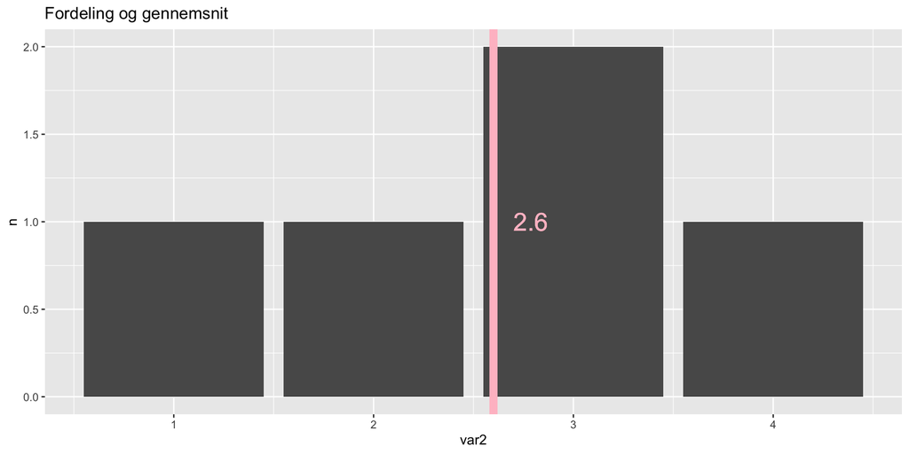

```r
df |>
  count(var2) |>
  ggplot() +
  aes(x = var2, y = n) +
  geom_col() +
  geom_vline(aes(xintercept = mean(df$var2)), linewidth = 3, color = "pink") +
  geom_text(aes(x = mean(df$var2) + .1, y = 1, label = mean(df$var2)), color = "pink", hjust = "left", size = 7) +
  labs(title = "Fordeling og gennemsnit")
```

## En variabels centrale tendens: gennemsnit

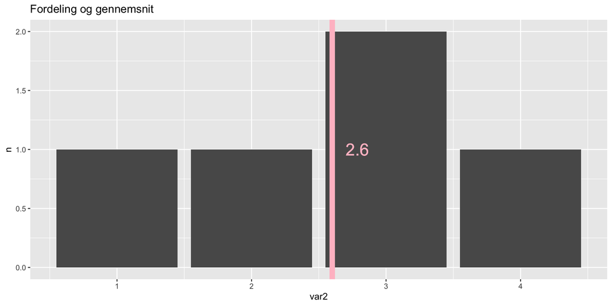

```r
df |>
  count(var2) |>
  ggplot() +
  aes(x = var2, y = n) +
  geom_col() +
  geom_vline(aes(xintercept = mean(df$var2)), linewidth = 3, color = "pink") +
  geom_text(aes(x = mean(df$var2) + .1, y = 1, label = mean(df$var2)), color = "pink", hjust = "left", size = 7) +
  labs(title = "Fordeling og gennemsnit")
```

- Kender I – også formlen!
- Kun numeriske variable (intervalskaleret/ordinal)
- Den mest informative (i betydningen: bygger på mange datapunkter)
- Ekstremt vigtig i statistik og kvantitativ forskning (af mange grunde)
  - fx i OLS-regression og kausal inferens om nogle uger
- *Altid* godt udgangspunkt til beskrivelse

## Gennemsnit af en binær variabel / ‘dummyfisering’

- Binære variable (0/1) er specielle, matematikken er særlig
- **Gennemsnittet af en binær variabel (0/1) = andelen**
  - dvs. andelen af 1’ere (“ja”), mellem 0 og 1
- Andele er nemme at forstå og kommunikere
- Reelt sådan vi laver statistik med nominelle variable → **andel “ja” for hver svarmulighed**

**Eksempel: Chikane af politikere**

- *Har du oplevet psykologisk chikane i valgkampen?*
  - Aldrig, 1 gang, 2-5 gange, 6 eller flere gange, Ved ikke
- Forsimples til dummy: 0 Aldrig, 1 Ja (1+ gange)
- Gennemsnit = ca. 64% (ja, 36% nej)
- Skjuler/reducerer variationen, men stærkt kommunikativt og enkelt analytisk
- Man skal kunne forsvare valget, når man smider information væk

## En variabels centrale tendens: median

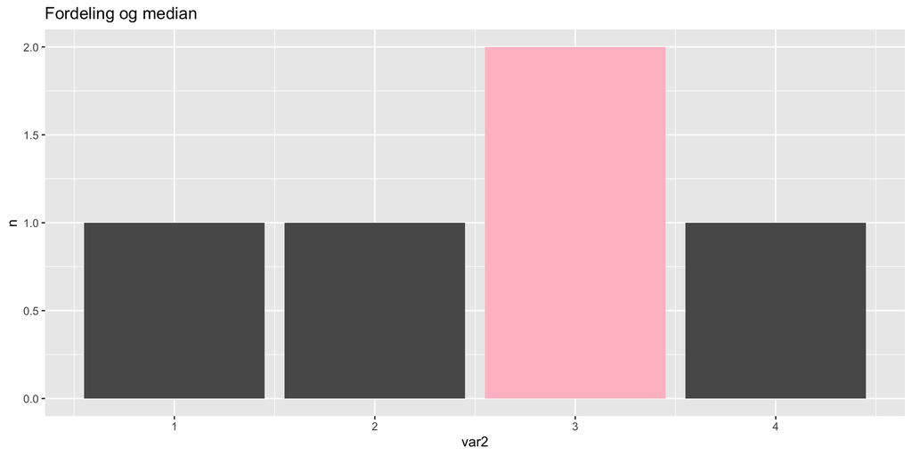

```r
df |>
  count(var2) |>
  mutate(median_obs = var2 == median(df$var2)) |>
  ggplot() +
  aes(x = var2, y = n, fill = median_obs) +
  geom_col() +
  scale_fill_manual(values = c("grey35", "pink")) +
  guides(fill = "none") +
  labs(title = "Fordeling og median")
```

- Medianen kender I også
- Vigtigt supplement
  - især når fordelingen er skæv (fx indkomst, eller pga. substantiel interesse)
  - ikke følsom over for outliers
- Men mindre informativ (ift. data)
- = 50%-percentilen

## En variabels centrale tendens: typetal

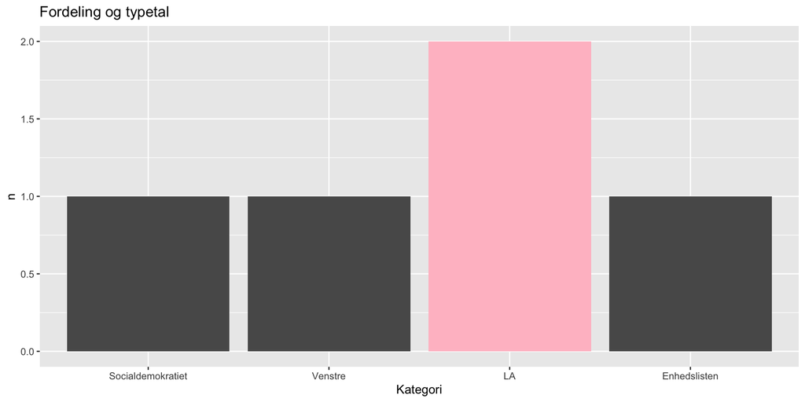

```r
df |>
  count(var2) |>
  mutate(median_obs = var2 == median(df$var2)) |>
  ggplot() +
  aes(x = factor(var2,
                 labels = c("Socialdemokratiet", "Venstre", "LA", "Enhedslisten")),
      y = n, fill = median_obs) +
  geom_col() +
  scale_fill_manual(values = c("grey35", "pink")) +
  guides(fill = "none") +
  labs(title = "Fordeling og typetal", x = "Kategori")
```

- Typetal kender I nok også
- Den hyppigst forekommende værdi → *typisk* i den forstand
  - men kan være langt fra gns og median
  - er fx ofte == *min*, *max* eller *missing*
- Godt supplement – ikke mindst til nominelt måleniveau

## Eksempel: politisk respekt for land og by

- Teoretisk begreb: ‘politisk respekt’
- “[gruppen] *bliver mødt med den respekt fra samfundet, som de fortjener*”
- Måles fra 0 (slet ikke) — 10 (I meget høj grad) → måleniveau?
- Data: Valgundersøgelsen 2022

## Eksempel: politisk respekt for land og by

> Hvordan kan vi beskrive graden af politisk respekt for hhv. land og by?

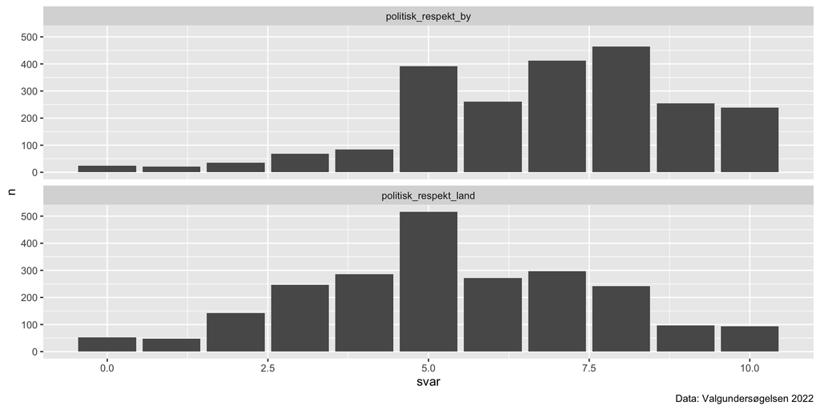

```r
pdata_respekt <- vu |>
  mutate(politisk_respekt_land = ifelse(Q36_2 %in% 0:10, Q36_2, NA),
         politisk_respekt_by = ifelse(Q36_7 %in% 0:10, Q36_7, NA)) |>
  select(politisk_respekt_land, politisk_respekt_by) |>
  pivot_longer(cols = c(politisk_respekt_land, politisk_respekt_by), names_to = "var", values_to = "svar")

pdata_respekt |>
  count(var, svar) |>
  ggplot() +
  aes(x = svar, y = n) +
  geom_col() +
  facet_wrap(~ var, ncol = 1) +
  labs(caption = "Data: Valgundersøgelsen 2022")
```

## Eksempel: politisk respekt for land og by

**Den centrale tendens: gennemsnit, median og typetal**

```r
pdata_respekt |>
  group_by(var) |>
  summarise(gns = mean(svar, na.rm = TRUE),
            median = median(svar, na.rm = TRUE),
            typetal = collapse::fmode(svar, na.rm = TRUE),
            andel_7_10 = round(mean(svar %in% 7:10, na.rm = TRUE), 2)) |>
  kable()
```

| var | gns | median | typetal | andel_7_10 |
| --- | --- | --- | --- | --- |
| politisk_respekt_by | 6.837838 | 7 | 8 | 0.48 |
| politisk_respekt_land | 5.341783 | 5 | 5 | 0.26 |

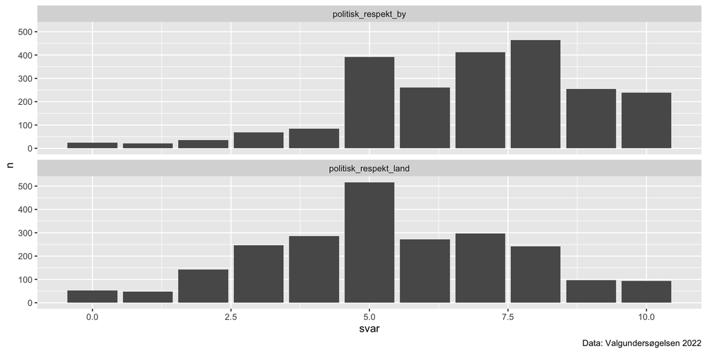

```r
pdata_respekt |>
  count(var, svar) |>
  ggplot() +
  aes(x = svar, y = n) +
  geom_col() +
  facet_wrap(~ var, ncol = 1) +
  labs(caption = "Data: Valgundersøgelsen 2022")
```

- Men vi mangler at kunne beskrive, hvor *(u)enige* vælgerne er → **spredningen**…

## En variabels spredning

- Vigtigste spredningsmål er **standardafvigelsen** (SD)
  - hvor ens/forskellige er værdierne/observationerne?
  - hvor anderledes fra gennemsnittet er de (samlet set)?
- SD bygger på **variansen:** $s^2 = \frac {\sum(Y_i-\hat{Y})^2}{n-1}$
  - Hvorfor $s^2$ (obs. fejl i MIS)? Hvorfor $n - 1$?

## Beregning af varians

*Lad os beregne **var3’s varians** (gns. ≈ 51): $s^2 = \frac {\sum(Y_i-\hat{Y})^2}{n-1}$*

```r
# step by step
df |>
  select(enhed_nr, var3) |>
  # 1: afvigelser fra gennemsnit
  mutate(afvigelse_fra_gns = var3 - mean(var3),
         # 2: kvadrér
         afvigelse2 = afvigelse_fra_gns^2,
         # 3: divider med (n - 1)
         afvigelse2_n = afvigelse2 / (n() - 1),
         sum_afvigelse2_n = sum(afvigelse2_n)) |>
  kable(digits = 2) |>
  kableExtra::kable_styling(font_size = 24) |>
  kableExtra::column_spec(2, background = "pink")
```

| enhed_nr | var3 | afvigelse_fra_gns | afvigelse2 | afvigelse2_n | sum_afvigelse2_n |
| --- | --- | --- | --- | --- | --- |
| 1 | 54.43 | 3.63 | 13.21 | 3.30 | 778.52 |
| 2 | 73.09 | 22.30 | 497.16 | 124.29 | 778.52 |
| 3 | 48.21 | -2.58 | 6.66 | 1.66 | 778.52 |
| 4 | 73.21 | 22.42 | 502.45 | 125.61 | 778.52 |
| 5 | 5.03 | -45.77 | 2094.61 | 523.65 | 778.52 |

```r
# eller i et enkelt træk:
var(df$var3)
```

```
[1] 778.5211
```

## Beregning af standardafvigelse

Kvadratroden af variansen: $s = \sqrt{s^2} = \sqrt{\frac {\sum(Y_i-\hat{Y})^2}{n-1}}$

```r
# kvadratroden af variansen
sqrt(var(df$var3))
```

```
[1] 27.90199
```

```r
# eller i et enkelt træk:
sd(df$var3)
```

```
[1] 27.90199
```

## Fortolkning af standardafvigelse

- Tilbage til variablens originale målestok (ish)
  - mellem 0 og variablens absolutte (positive) maksimum
- Ikke den typiske *værdi*, men…

> **Den typiske *afvigelse* fra den typiske værdi** (gennemsnittet)
- Den gennemsnitlige/forventede afvigelse
- Derfor er gennemsnit og standardafvigelse et stærkt makkerpar
- Helt centrale i statistik

## Fortolkning af standardafvigelse

*Std.afv. (SD) er beregnet relativt til gennemsnittet og kan illustreres sådan (i begge retninger)*

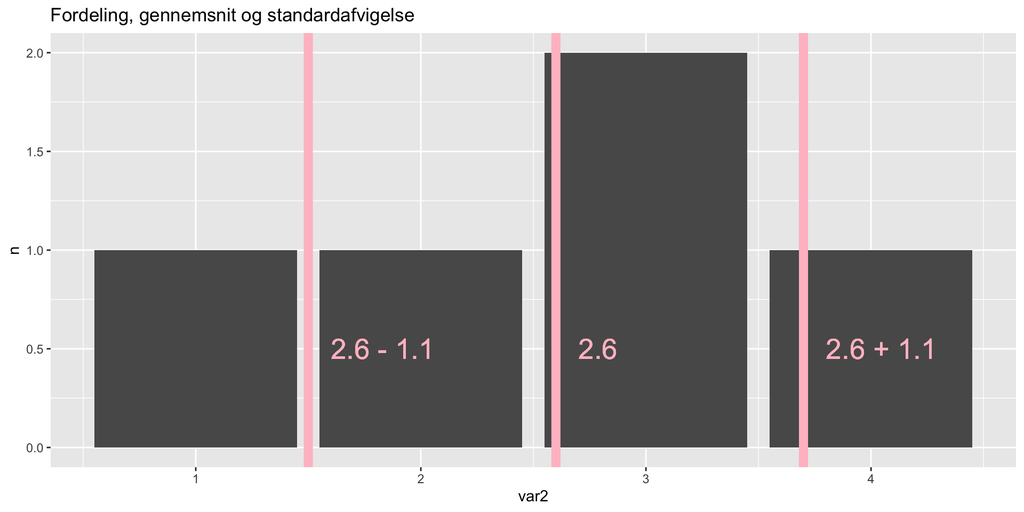

```r
gns <- round(mean(df$var2), 1)
std_afvigelse <- round(sd(df$var2), 1)

df |>
  count(var2) |>
  ggplot() +
  aes(x = var2, y = n) +
  geom_col() +
  geom_vline(aes(xintercept = gns), linewidth = 3, color = "pink") +
  geom_vline(aes(xintercept = gns - std_afvigelse), linewidth = 3, color = "pink") +
  geom_vline(aes(xintercept = gns + std_afvigelse), linewidth = 3, color = "pink") +
  geom_text(aes(x = gns + .1, y = .5, label = gns), color = "pink", hjust = "left", size = 7) +
  geom_text(aes(x = gns + std_afvigelse + .1, y = .5, label = paste0(gns, " + ", std_afvigelse)), color = "pink", hjust = "left", size = 7) +
  geom_text(aes(x = gns - std_afvigelse + .1, y = .5, label = paste0(gns, " - ", std_afvigelse)), color = "pink", hjust = "left", size = 7) +
  labs(title = paste0("Fordeling, gennemsnit og standardafvigelse"))
```

## Eksempel: politisk respekt for land og by

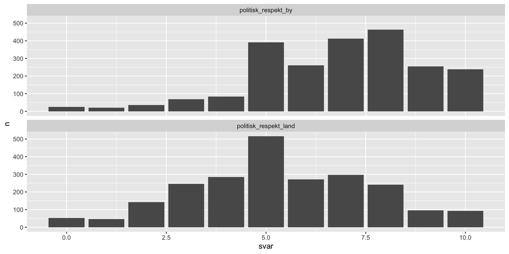

```r
pdata_respekt |>
  count(var, svar) |>
  ggplot() +
  aes(x = svar, y = n) +
  geom_col() +
  facet_wrap(~ var, ncol = 1)
```

- **Hvor uenige/spredte var vælgerne så i deres mening om politisk respekt for land/by?**
  - mest uenige/spredte/usikre (?) om land eller om by?
- Vi kan beregne standardafvigelsen vha. `tidystats::describe_data(data, var)`

```r
bind_rows(
  # deskriptiv statistik (standardafvigelse) for land
  pdata_respekt |>
    filter(var == "politisk_respekt_land") |>
    tidystats::describe_data(svar) |>
    mutate(var = "politisk_respekt_land"),

  # deskriptiv statistik (standardafvigelse) for by
  pdata_respekt |>
    filter(var == "politisk_respekt_by") |>
    tidystats::describe_data(svar) |>
    mutate(var = "politisk_respekt_by")
) |>
  mutate(kurtosis = kurtosis - 3) |>
  kable() |>
  kableExtra::kable_styling(font_size = 24) |>
  kableExtra::column_spec(5, background = "pink")
```

| var | missing | N | M | SD | SE | min | max | range | median | mode | skew | kurtosis |
| --- | --- | --- | --- | --- | --- | --- | --- | --- | --- | --- | --- | --- |
| politisk_respekt_land | 535 | 2288 | 5.341783 | 2.275968 | 0.0475815 | 0 | 10 | 10 | 5 | NA | -0.0383719 | -0.3719142 |
| politisk_respekt_by | 566 | 2257 | 6.837838 | 2.119716 | 0.0446182 | 0 | 10 | 10 | 7 | NA | -0.6433758 | 0.3826581 |

## Spredningsmål (fortsat)

```r
kable(df) |>
  kableExtra::column_spec(3, background = "pink")
```

| enhed_nr | var1 | var2 | var3 |
| --- | --- | --- | --- |
| 1 | e | 2 | 54.42901 |
| 2 | d | 3 | 73.09180 |
| 3 | a | 4 | 48.21485 |
| 4 | a | 1 | 73.21021 |
| 5 | a | 3 | 5.02785 |

*Standardafvigelsen for **var2** var 1.1*

## Spredningsmål (fortsat)

#### Variationsbredde (range)

```r
# range (variationsbredde) som min og max
min(df$var2)
```

```
[1] 1
```

```r
max(df$var2)
```

```
[1] 4
```

```r
range(df$var2)
```

```
[1] 1 4
```

```r
# range (variationsbredde) som afstand mellem min og max
diff(range(df$var2))
```

```
[1] 3
```

## Spredningsmål (fortsat)

#### Interkvartil-range (IQR)

```r
# kvartiler: 25% og 75% (50% = median, 0% = min, 100% = max)
quantile(df$var2)
```

```
  0%  25%  50%  75% 100%
   1    2    3    3    4
```

```r
# IQR = 75% - 25%
IQR(df$var2)
```

```
[1] 1
```

## Skævhed

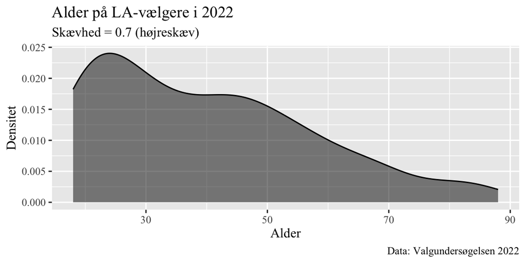

```r
pdata <- vu |>
  mutate(x = ifelse(alder_på_valgdag %in% 18:98, alder_på_valgdag, NA)) |>
  filter(!is.na(x), parti22 %in% 9)

pdata |>
  ggplot() +
  aes(x = x, fill = labelled::to_factor(parti22)) +
  geom_density(alpha = 0.5, fill = "black") +
  labs(x = "Alder", y = "Densitet", fill = "Parti", title = "Alder på LA-vælgere i 2022", subtitle = paste0("Skævhed = ", round(moments::skewness(pdata$x), 2), " (højreskæv)"), caption = "Data: Valgundersøgelsen 2022") +
  theme(text = element_text(family = "Times New Roman"))
```

- **Skævhed** er et vigtigt koncept til at beskrive en fordeling
- Har oftest en klar, substantiel betydning/fortolkning
- … men vi beregner det sjældent nøjagtigt

## Spidshed

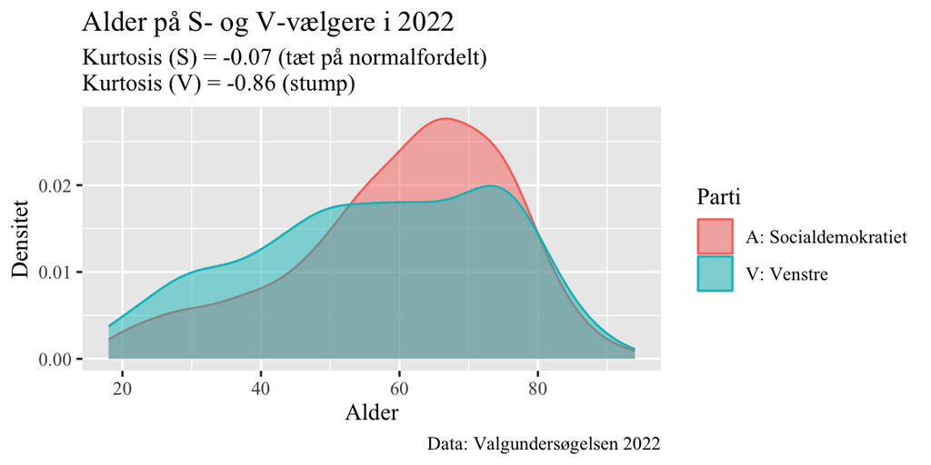

```r
pdata <- vu |>
  mutate(x = ifelse(alder_på_valgdag %in% 18:98, alder_på_valgdag, NA)) |>
  filter(!is.na(x), parti22 %in% c(1, 22))

pdata |>
  ggplot() +
  aes(x = x, fill = labelled::to_factor(parti22), color = labelled::to_factor(parti22)) +
  geom_density(alpha = .5) +
  # obs! Husk at trække 3 fra den "rå" kurtosis, jf. MIS-formel
  labs(x = "Alder",
       y = "Densitet",
       title = "Alder på S- og V-vælgere i 2022",
       subtitle = paste0("Kurtosis (S) = ", round(moments::kurtosis(pdata$x[pdata$parti22 == 1]) - 3, 2), " (tæt på normalfordelt)\n",
                         "Kurtosis (V) = ", round(moments::kurtosis(pdata$x[pdata$parti22 == 22]) - 3, 2), " (stump)"),
       color = "Parti",
       fill = "Parti",
       caption = "Data: Valgundersøgelsen 2022") +
       theme(text = element_text(family = "Times New Roman"))
```

- **Spidshed (kurtosis)** er lidt mindre vigtigt
- … men spiller en vigtig rolle fx i sandsynlighedsfordelinger

# Opsummering af måling og deskriptiv statistik

## Opsummering

- Måleniveauer: nominelt (kategorisk), ordinalt, intervalskaleret
- **Måleniveauet er et valg** i analysen med fordele, ulemper og implikationer
  - led i operationaliseringen, vigtigt i statskundskaben
- **Deskriptiv statistik:**
  - vi bruger det hele tiden, bevidst og ubevidst
  - vi kan ligeså godt være præcise og systematiske
  - beskriver en fordeling
  - central tendens er særligt nyttigt
  - især gennemsnit og standardafvigelse
- Bruges i beskrivende analyser, men er også kernen i forklarende/kausale metoder

## Næste uge

- **Datavisualisering**
- Meget hands-on (R og *ggplot2*)
- Bruges allerede – fortsætter senere
- Nyttigt i opgaver, eksamener og jobs

### Giv spørgeskemaet et sidste forsøg

https://019b30f0-735b-1f9a-5a5f-58b81a6121a0.share.connect.posit.cloud/?completion_code=m1f26

https://kortlink.dk/2u5uh